# PDF Scraping - Hackathon

PDF scraping group

2023-09-21

# 1 Background and Rationale

In the field of epidemiology, the rapid and accurate extraction of data from various sources, including situation reports on disease outbreaks, is critical for monitoring, understanding, and responding to public health crises. Situation reports are often released by health organizations, governmental bodies, and international agencies to provide up-to-date information on the progression and impact of outbreaks. However, these reports are frequently published in PDF format, which poses significant challenges for data extraction. PDF scraping solutions can empower modelers, epidemiologists and public health professionals to efficiently extract, analyze, and act on crucial epidemiological data, ultimately contributing to better preparedness, response, and control of infectious disease outbreaks.

## 1.1 Objective

As a project in the 2023 Early stage outbreaks analytics hackathon, at the WHO Berlin Hub, we set out to document and test PDF scraping tools. The objective of this work is to explore and highlight the suitability, advantages and limitations of existing PDF scraping solutions.

## 1.2 Approach

Our approach comprised the evaluation of selected R and Python packages, text and image recognition methods, and the utilization of Large Language Model (LLM) capabilities for extraction of data from PDF with varying degrees of complexity.

# 2 Example PDFs

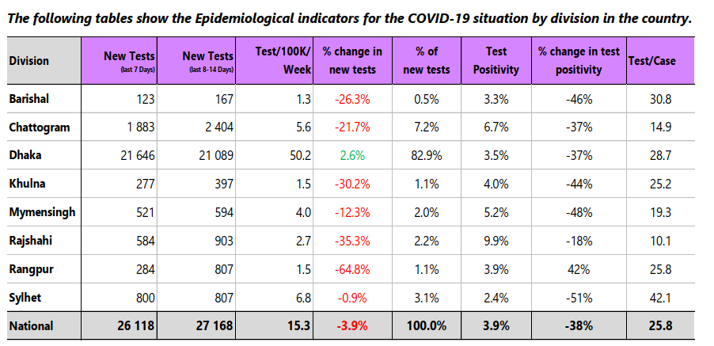

Target scraping table

This table is relatively easy to scrape for several reasons:

1. It has a simple layout with no merged cells
2. It is embedded as text in the PDF, rather than as an image
3. It’s written in English
4. It’s fully contained on a single page of the PDF

Changes to these or other factors can make PDF scraping significantly more challenging.

# 3 Summary of evaluated tools

We evaluated the following tools, via R and python:

| Approach | Ease of installation | Ease of use | Value accuracy | Table structure complexity | Image parsing |
| --- | --- | --- | --- | --- | --- |
| Tabulizer (Tabula API) | Medium | High | High | Medium | No |
| Text parsing | High | Medium | High | Low | No |
| OCR | Medium* | Medium | Low | High | Yes |